# Annotations AltText and Captions

## Palmer’s Penguins

```r
data("penguins") #loads penguin data sets
pengs <- penguins_raw |>
  janitor::clean_names() |>
  #on the left are the new names we are giving the penguin species. On the right are the orinal names in the dataset
  mutate(species = fct_recode(species,
             Adelie = "Adelie Penguin (Pygoscelis adeliae)",
             Gentoo = "Gentoo penguin (Pygoscelis papua)",
             Chinstrap = "Chinstrap penguin (Pygoscelis antarctica)"))

#see all the variable names
names(pengs)
```

```
 [1] "study_name"        "sample_number"     "species"
 [4] "region"            "island"            "stage"
 [7] "individual_id"     "clutch_completion" "date_egg"
[10] "culmen_length_mm"  "culmen_depth_mm"   "flipper_length_mm"
[13] "body_mass_g"       "sex"               "delta_15_n_o_oo"
[16] "delta_13_c_o_oo"   "comments"
```

## Add Faceted Annotations

Create the original faceted plot

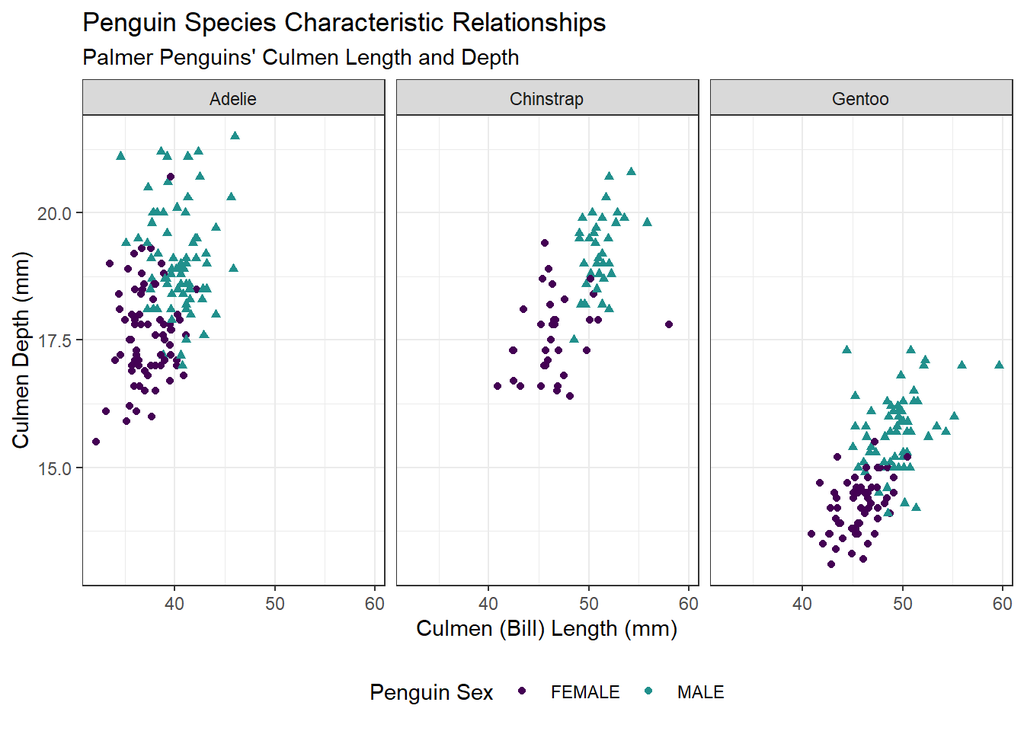

```r
p <- pengs |>
  drop_na(sex) |>
  ggplot(aes(x = culmen_length_mm, y = culmen_depth_mm)) +
  geom_point(aes(color = sex, shape = sex), size = 1.5) + #could be added in ggplot() line as well
  labs(x = "Culmen (Bill) Length (mm)",
       y = "Culmen Depth (mm)",
       title = "Penguin Species Characteristic Relationships",
       subtitle = "Palmer Penguins' Culmen Length and Depth",
       color = "Penguin Sex") +
  theme_bw() +
  scale_color_viridis_d(begin = 0, end = 0.5) +
  facet_wrap(~species) +
  guides(shape = "none") +
  theme(legend.position = "bottom")

p
```

### Add basic annotations

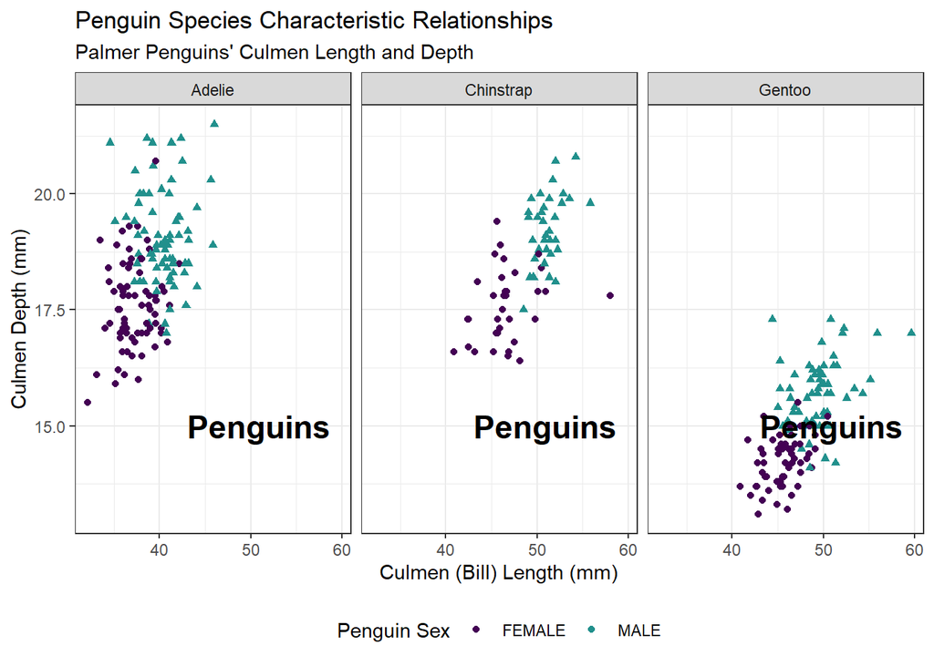

```r
#If I have a faceted graph, then by default the annotation will appear in the same place on each facet
p +
  annotate(geom = "text", x=43, y=15, label = "Penguins", hjust="left", fontface="bold", size = 6)
```

### Add specific annotations to each facet

```r
#We need to use geom_text if we want to get a different annotation on each facet

#First we create a data frame (a matrix) that include all the labels (annotations), which facet we want the labels on, and the coordinates of the labels.
#You should specify the label for EACH facet, even if one is going to be blank. In this example, I am leaving the Chinstrap facet without an annotation
#\n Means "new line" and will let you annotation span several lines. Compare Adelie vs Gentoo
#species is the variable name that I used for faceting, so here I specify the levels of the variable I facet on to match where the annotations should go
#then I give x and y coordinates for the annotations

dat_text <- data.frame(
  label = c("Adelie \nPenguins", "", "Gentoo Penguins"),
  species   = c("Adelie", "Chinstrap", "Gentoo"),
  x     = c(40, 40, 45),
  y     = c(15, 15, 20)
  )
#see what the matrix of annotations looks like
dat_text
```

```
              label   species  x  y
1 Adelie \nPenguins    Adelie 40 15
2                   Chinstrap 40 15
3   Gentoo Penguins    Gentoo 45 20
```

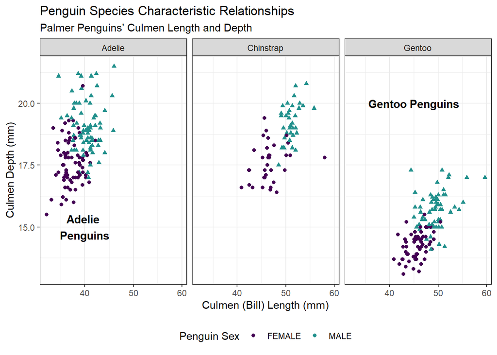

```r
#Now add the text onto the graph, customzing size and font as well
p + geom_text(data = dat_text,
              mapping = aes(x = x, y = y, label = label),
              hjust = "center", size = 4, fontface = "bold")
```

If you want more examples of annotations on facets, see here: https://stackoverflow.com/questions/11889625/annotating-text-on-individual-facet-in-ggplot2

Note that you can use the same concept to add arrows, circles, etc

## Add Data Source in a Caption

We know that an important aspect of deciding if we can trust a visualization is knowing the data source. In news articles or grahs that will be widely shared, it is important for the data source to be referenced on the graphic itself. The easiest way to do this is in a caption. This will add the caption in the bottom right corner of the graphic.

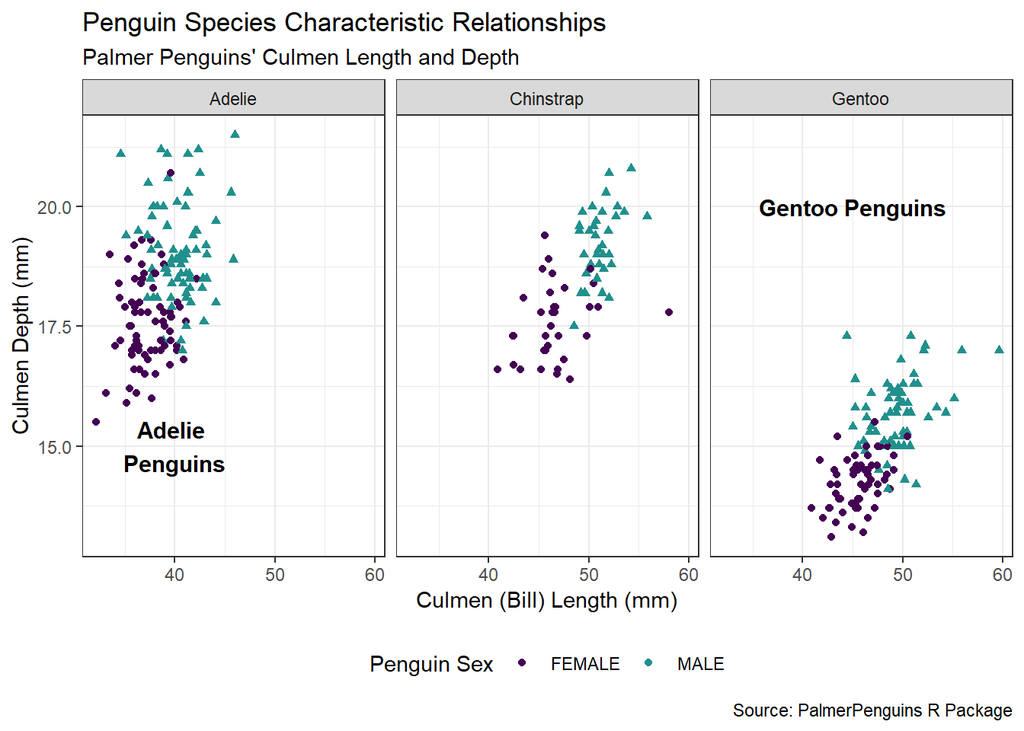

```r
#Keep layering on to the original plot
p + geom_text(data = dat_text,
              mapping = aes(x = x, y = y, label = label),
              hjust = "center", size = 4, fontface = "bold") +
  labs(caption = "Source: PalmerPenguins R Package")
```

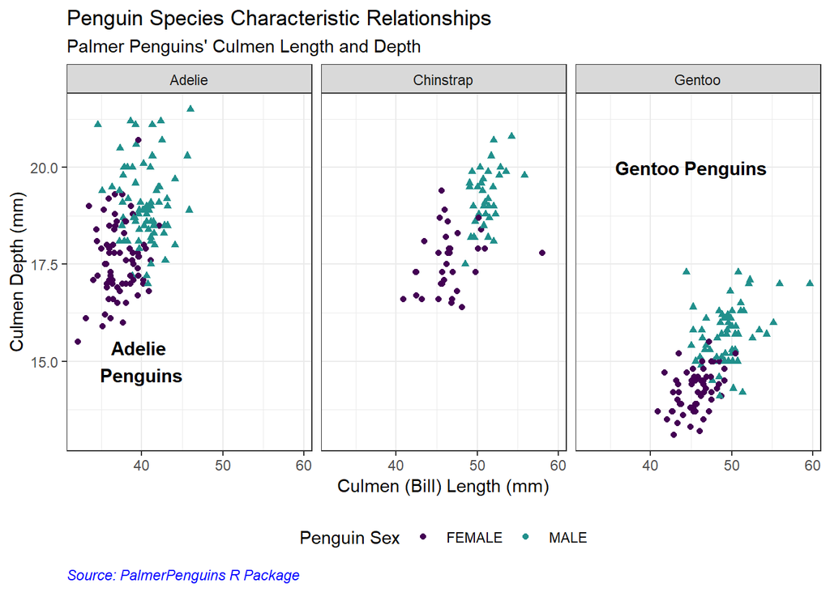

```r
#You can change the location of the caption, font, etc by editing the THEME of the graph
#hjust of 0 justifies the text to the left instead of right

p + geom_text(data = dat_text,
              mapping = aes(x = x, y = y, label = label),
              hjust = "center", size = 4, fontface = "bold") +
  labs(caption = "Source: PalmerPenguins R Package") +
  theme(plot.caption = element_text(hjust = 0, face = "italic", color = "blue"))
```

## Add Alt Text

As we learned in the reading, Alt Text can easily be added with the`fig-alt` chunk option. Remember alt text should give a detailed description of the chart for a person who is unable to see the graph.

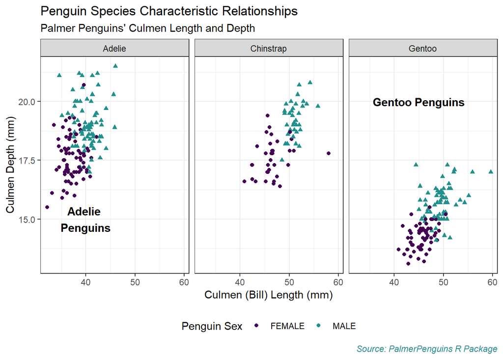

```r
#See the 2 places you can put alt text in this code chunk - which one works when you inspect the graph after rendering?

#Keep layering on to the original plot
p2 <- p + geom_text(data = dat_text,
              mapping = aes(x = x, y = y, label = label),
              hjust = "center", size = 4, fontface = "bold") +
  labs(caption = "Source: PalmerPenguins R Package",
       alt = "Does this alt text work? No!") +
  theme(plot.caption = element_text(hjust = 1, face = "italic", color = "#238A8DFF"))

p2
```

```r
#Save the graph. Now a person using a screen reader will be able to hear a description of the graph!
ggsave("penguins_alt.png", plot = p2, device = "png", )
```